# Classifying Toxic Comments with an LSTM model

# Introduction

This dataset consists of one input column with 6 different output classes. We can either view it as a multi class multi label classification model or a binary classification model with 6 different output classes. Lets check if there are any null values that we have to deal with.

# Import Modules

```python
import sys, os, re, csv, codecs, numpy as np, pandas as pd
import matplotlib.pyplot as plt
%matplotlib inline
from keras.preprocessing.text import Tokenizer
from keras.utils import pad_sequences
from keras.layers import Dense, Input, LSTM, Embedding, Dropout, Activation
from keras.layers import Bidirectional, GlobalMaxPool1D
from keras.models import Model
from keras import initializers, regularizers, constraints, optimizers, layers
```

# Import Data

We will import the data and check if there are any null values. Luckily we have none! We can proceed

```python
train = pd.read_csv('./train.csv')
```

```python
train.isnull().any()
```

```
id               False
comment_text     False
toxic            False
severe_toxic     False
obscene          False
threat           False
insult           False
identity_hate    False
dtype: bool
```

```python
from sklearn.model_selection import train_test_split
list_classes = ["toxic", "severe_toxic", "obscene", "threat", "insult", "identity_hate"]
x_train, x_val, y_train, y_val = train_test_split(train['comment_text'], train[list_classes], test_size=0.1, random_state=42)

y_t = y_train.values
y_v = y_val.values
```

Just to get a glimpse of how the dataset looks like, lets take a look at a few sentences that are labeled “identity_hat” or supposedly the most suvere form of toxic speech.

```python
x_train[train['identity_hate'] == 1].head()
```

```
88090     It pains my heart to find out that Wikepedia e...
34903     It's \n\nGo Go Jewranger\nGo Go Jewranger\nHar...
156437    HUGE FAGGOT HUGE FAGGOT HUGE FAGGOT HUGE FAGGO...
79565     JEW FUCKING POWER!!!!!!!\n\nFOR ALLAH!!!!! *BOOM*
137002                        crazy nerd who dislikes women
Name: comment_text, dtype: object
```

Yikes…So lets get to work and see how well we can classify toxic speech!

# Data Manipulation

## Tokenizing Sentences

We’ll tokenize the sentence but only keep words that appear for the top 20000. I guess technically the more features the better, but since we’re running on a limited amount of resources(a single laptop) we’ll keep it at 20000. We’ll use the Tokenizer funciton from keras to train based on the training dataset and tokenize the validation dataset based on the tokenizer we’ve trained

```python
max_features = 20000
tokenizer = Tokenizer(num_words=max_features)
tokenizer.fit_on_texts(list(x_train))
list_tokenized_train = tokenizer.texts_to_sequences(x_train)
list_tokenized_val = tokenizer.texts_to_sequences(x_val)
```

## Padding

Sentences are all different types of lengths. in order to fit this into a model, we will have to make them the same length. we’ll use the pad_sequence from keras to pad extra numbers to the left of the tokenized sentence. We’ll pad the left becaues we’ll be using an lstm model where the order matters and the more recent values have a higher say in classifying the data.

```python
maxlen = 200
X_t = pad_sequences(list_tokenized_train, maxlen=maxlen)
X_v = pad_sequences(list_tokenized_val, maxlen=maxlen)
```

```python
totalNumWords = [len(i) for i in list_tokenized_train]
pd.Series(totalNumWords).describe()
```

```
count    143613.000000
mean         65.684367
std          97.522542
min           0.000000
25%          16.000000
50%          35.000000
75%          73.000000
max        1400.000000
dtype: float64
```

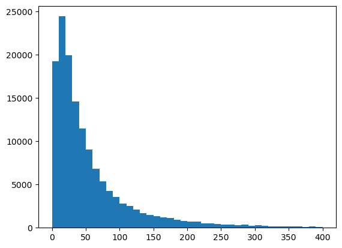

```python
plt.hist(totalNumWords,bins = np.arange(0,410,10))#[0,50,100,150,200,250,300,350,400])#,450,500,550,600,650,700,750,800,850,900])
plt.show()
```

# Modeling

## Import Modules

```python
import tensorflow as tf

from keras import models
from keras import layers
from keras.callbacks import EarlyStopping
from keras.regularizers import l1, l2
from keras.optimizers import Adam
from sklearn.utils.class_weight import compute_class_weight
import keras.backend as K
from keras.callbacks import Callback
```

## Metric functions

I’ll define a few metric functions that I might want to track during the trianing process while training my model in keras. Keras has built it accuracy tracking but doesn’t have precision, f1 or recall, so I’ll define a function to track them when needed.

```python
def precision(y_true, y_pred):
    true_positives = tf.keras.backend.sum(tf.keras.backend.round(tf.keras.backend.clip(y_true * y_pred, 0, 1)))
    predicted_positives = tf.keras.backend.sum(tf.keras.backend.round(tf.keras.backend.clip(y_pred, 0, 1)))
    precision_val = true_positives / (predicted_positives + tf.keras.backend.epsilon())
    return precision_val

def f1_score(y_true, y_pred):
    true_positives = K.sum(K.round(K.clip(y_true * y_pred, 0, 1)))
    possible_positives = K.sum(K.round(K.clip(y_true, 0, 1)))
    predicted_positives = K.sum(K.round(K.clip(y_pred, 0, 1)))
    precision = true_positives / (predicted_positives + K.epsilon())
    recall = true_positives / (possible_positives + K.epsilon())
    f1 = 2 * (precision * recall) / (precision + recall + K.epsilon())
    return f1

def recall(y_true, y_pred):
    true_positives = K.sum(K.round(K.clip(y_true * y_pred, 0, 1)))
    possible_positives = K.sum(K.round(K.clip(y_true, 0, 1)))
    recall = true_positives / (possible_positives + K.epsilon())
    return recall
```

## Training the model

Now for the model.

We’re just going to create a simple model where we can tune a few hyper-parameters such as L1, L2 regularization, dropout, embedding sizes, batch size and number of epochs.

We start off the model with an embedding, pass it through an LSTM layer, go through max pooling, add a layer of dropout and feed it into a dense ANN layer to retrieve an output of one class.

For out test, we will focus on the first column of the dependent variable which is why the variable cat is set to 0.

```python
from keras import models
from keras import layers
from keras.callbacks import EarlyStopping
from keras.regularizers import l1, l2
from keras.optimizers import Adam

cat = 0
L1 = 0
L2 = 0
drop = 0.1
max_features = 20000
embed_size = 128
batch_size = 32
epochs = 2

y = y_t[:,cat]

# Create a sequential model
model = models.Sequential()

# Add layers to the model
model.add(layers.Embedding(max_features, embed_size, input_length=maxlen))
model.add(layers.LSTM(60, return_sequences=True, name='lstm_layer'))
model.add(layers.GlobalMaxPool1D())
model.add(layers.Dropout(drop))
model.add(layers.Dense(50, activation="relu", kernel_regularizer=l1(L1)))
model.add(layers.Dropout(drop))
model.add(layers.Dense(1, activation="sigmoid"))

# Compile the model
model.compile(loss='binary_crossentropy',
              optimizer=Adam(),
              metrics=[f1_score,'accuracy'])

# Training
history = model.fit(
    X_t, y,
    epochs=epochs,
    batch_size=batch_size,
    validation_split=0.1,
    callbacks=[EarlyStopping(monitor='val_loss', patience=3, restore_best_weights=True)]
)
```

## Confusion Matrix

We’ll make a confusion matrix and print out our metrics to see how we did

```
toxic Accuracy: 0.9632159418473493
toxic F1 Score: 0.7734465457352374
toxic Recall : 0.677027027027027
toxic Precision: 0.9018901890189019
```

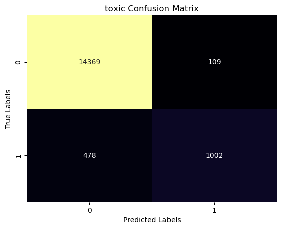

```python
import seaborn as sns
import matplotlib.pyplot as plt
from sklearn.metrics import confusion_matrix
from sklearn import metrics
from sklearn.metrics import confusion_matrix, accuracy_score, f1_score, recall_score, precision_score

cat = 0

pred_val = model.predict(X_v)
y_pred = pred_val.copy().flatten()
y_predict = [1 if i > 0.5 else 0 for i in y_pred]

y_true = y_v[:,cat]

cm = confusion_matrix(y_true, y_predict)

# Create a heatmap using seaborn
sns.heatmap(cm, annot=True, fmt="d", cmap="inferno", cbar=False)

# Add labels and title
plt.xlabel("Predicted Labels")
plt.ylabel("True Labels")
plt.title(f"{list_classes[cat]} Confusion Matrix")

# Display the plot
plt.show()

# Calculate accuracy
accuracy = accuracy_score(y_true, y_predict)
print(f"{list_classes[cat]} Accuracy:", accuracy)

# Calculate F1 score
f1 = f1_score(y_true, y_predict)
print(f"{list_classes[cat]} F1 Score:", f1)

# Calculate recall score
recall = recall_score(y_true, y_predict)
print(f"{list_classes[cat]} Recall :", recall)

# Calculate precision score
precision = precision_score(y_true, y_predict)
print(f"{list_classes[cat]} Precision:", precision)
```

Not bad, but it seems like we could make it a bit better just by tuning the threshold. We can see that the precision is much higher than the recall score. Lets see if we can optimize the threshold.

## Choosing a threshold

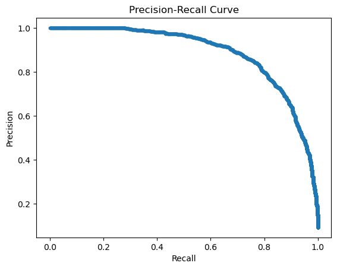

```
Best threshold: 0.28480342
Best F1 score: 0.8057103063567322
```

```python
from sklearn.metrics import precision_recall_curve
# Assuming y_true contains true labels and y_pred contains predicted probabilities
precision, recall, thresholds = precision_recall_curve(y_true, y_pred)

# Now you have precision, recall, and thresholds
import matplotlib.pyplot as plt

plt.plot(recall, precision, marker='.')
plt.xlabel('Recall')
plt.ylabel('Precision')
plt.title('Precision-Recall Curve')
plt.show()
# Compute F1 score for each threshold
f1_scores = 2 * (precision * recall) / (precision + recall + 1e-10)  # Avoid division by zero

# Find the index of the threshold that maximizes F1 score
best_threshold_index = np.argmax(f1_scores)

# Use the corresponding threshold
best_threshold = thresholds[best_threshold_index]
best_f1_score = f1_scores[best_threshold_index]

print("Best threshold:", best_threshold)
print("Best F1 score:", best_f1_score)
```

## Revaluating model with new thershold

Now that we have an optimal threshold, lets put this into our prediciton and see how our confusion matrix and our evaluation metrics change!

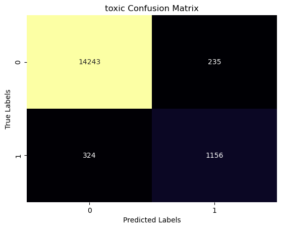

```
toxic Accuracy: 0.9649705476876802
toxic F1 Score: 0.8052943225357019
toxic Recall : 0.7810810810810811
toxic Precision: 0.8310567936736161
```

```python
import seaborn as sns
import matplotlib.pyplot as plt
from sklearn.metrics import confusion_matrix
from sklearn import metrics
from sklearn.metrics import confusion_matrix, accuracy_score, f1_score, recall_score, precision_score

cat = 0

# pred_val = model.predict(x_val)
# y_pred = pred_val.copy().flatten()
y_predict = [1 if i > best_threshold else 0 for i in y_pred]

y_true = y_v[:,cat]

cm = confusion_matrix(y_true, y_predict)

# Create a heatmap using seaborn
sns.heatmap(cm, annot=True, fmt="d", cmap="inferno", cbar=False)

# Add labels and title
plt.xlabel("Predicted Labels")
plt.ylabel("True Labels")
plt.title(f"{list_classes[cat]} Confusion Matrix")

# Display the plot
plt.show()

# Calculate accuracy
accuracy = accuracy_score(y_true, y_predict)
print(f"{list_classes[cat]} Accuracy:", accuracy)

# Calculate F1 score
f1 = f1_score(y_true, y_predict)
print(f"{list_classes[cat]} F1 Score:", f1)

# Calculate recall score
recall = recall_score(y_true, y_predict)
print(f"{list_classes[cat]} Recall :", recall)

# Calculate precision score
precision = precision_score(y_true, y_predict)
print(f"{list_classes[cat]} Precision:", precision)
```

We can see that the confusion matrix is much more evened out throughout the False positives and False negatives. The precision went down, recall went up and the f1 score is at its maximum.

# Conclusion

## Analyze misclassified labels

So now that our model is optimized, lets look at the mis-classified labels. Sometimes its not entirely the algorithm’s fault that its not a 100% accurate. Its hard for humans to tell the difference so lets give it a closer look

## False Positives

```python
a = x_val.to_list()
```

```python
FP = ((np.array(y_predict) ==1) & (y_true == 0))
FP = np.where(FP == 1)[0]

result_list = [a[index] for index in FP]

result_list[:20]
```

```
["That's just a web site with no academic authority.  Just because you are providing a link doesn't mean you can include any bullshit that you want in Wikipedia articles.  Here is a link to Iranica's index, witth multiple entries on both Afghanistand and Aryana.  Show me where it says Aryana or Aria…
 'Ram it up ur ass very hard till ur eyes water',
 'LIVE FREE OR DIE TRYING!',
 'Wow J Delanoy, you must really love Brit Hume and hate science!!!!!',
 '"\n\n You\'re famous! \n\nIt looks like you\'ve finally gotten the recognition you deserve: , you inbred little kite. "',
 'JFBurton User Page \n\nYour not an administrator and stop acting like you are one. People add stuff to my user page all the time. Grow Up.',
 "Seriously \n\nSeriously dude, quit it, you're going to get our school banned. And when we get b&, we get Party V&.",
 "We've been over this a thousand times and your comment is not a constructive one.  Not every picture of a sexual act is pornography.",
 '"\n\nVery nice. I am being harassed, my editing was disrupted and now I got blocked ""for harassment"". I am out of here, you bullies.   "',
 "[I am sorry, I wrote this stupid sentence at about 2 o'clock in the night; the definition is perfectly correct and even well written]",
 '"\n please consider this as a personal attack against the user ""Node eu""\nDear ""Node Eu"" I do take personal pride and honor to say to you and your commander an well deserved ""Fuck you !!"" and yes I know as this moment your real identity ( please forgive me wikipedia). I want to assure you an…
 'Youre a homo for protectin Archbelwtfishisnameanyway user page. Lol, I use that to find my contribs lol. (I hope you know that I do this for fun, and youre not gonna find my real account)72.138.216.89',
 '"\n\n A brownie for you! \n\n  sweet for sweet girl..) Padmaja kulkarni "',
 'the block page says I should add this to my page so there it goes. Someone fix this and get these power corrupt idiots to stop stalking me.',
 "why can't you get yourself a girl?  are you that ugly or are you that ugly and that awkward and that much of a failure? \n\n)\n\ni bookmarked your user page... you'll be hearing from me regularly, ugly.\n\nguess you wont be able to hide from life on wikipedia anymore.",
 'the chicks they scream\n(duh duh)\nat grease lightnin\ngrease lightnin, go go go go go go go go go!',
 'I AM GAY\nLove\n  \nI AM GAY\nLove',
 "Can you just do me a favour for a minute. Stop your private little vendetta against me and stay the hell away from my user page. If it offended you then don't read it. (  )",
 'Like I said tricks are for losers, and its also a two way street.',
 'Now \n\nI still think you are doo doo.\n\nYes, doo doo indeed.']
```

```python
FN = ((np.array(y_predict) ==0) & (y_true == 1))
FN = np.where(FP == 1)[0]

result_list = [a[index] for index in FP]

result_list[:20]
```

```
["That's just a web site with no academic authority.  Just because you are providing a link doesn't mean you can include any bullshit that you want in Wikipedia articles.  Here is a link to Iranica's index, witth multiple entries on both Afghanistand and Aryana.  Show me where it says Aryana or Aria…
 'Ram it up ur ass very hard till ur eyes water',
 'LIVE FREE OR DIE TRYING!',
 'Wow J Delanoy, you must really love Brit Hume and hate science!!!!!',
 '"\n\n You\'re famous! \n\nIt looks like you\'ve finally gotten the recognition you deserve: , you inbred little kite. "',
 'JFBurton User Page \n\nYour not an administrator and stop acting like you are one. People add stuff to my user page all the time. Grow Up.',
 "Seriously \n\nSeriously dude, quit it, you're going to get our school banned. And when we get b&, we get Party V&.",
 "We've been over this a thousand times and your comment is not a constructive one.  Not every picture of a sexual act is pornography.",
 '"\n\nVery nice. I am being harassed, my editing was disrupted and now I got blocked ""for harassment"". I am out of here, you bullies.   "',
 "[I am sorry, I wrote this stupid sentence at about 2 o'clock in the night; the definition is perfectly correct and even well written]",
 '"\n please consider this as a personal attack against the user ""Node eu""\nDear ""Node Eu"" I do take personal pride and honor to say to you and your commander an well deserved ""Fuck you !!"" and yes I know as this moment your real identity ( please forgive me wikipedia). I want to assure you an…
 'Youre a homo for protectin Archbelwtfishisnameanyway user page. Lol, I use that to find my contribs lol. (I hope you know that I do this for fun, and youre not gonna find my real account)72.138.216.89',
 '"\n\n A brownie for you! \n\n  sweet for sweet girl..) Padmaja kulkarni "',
 'the block page says I should add this to my page so there it goes. Someone fix this and get these power corrupt idiots to stop stalking me.',
 "why can't you get yourself a girl?  are you that ugly or are you that ugly and that awkward and that much of a failure? \n\n)\n\ni bookmarked your user page... you'll be hearing from me regularly, ugly.\n\nguess you wont be able to hide from life on wikipedia anymore.",
 'the chicks they scream\n(duh duh)\nat grease lightnin\ngrease lightnin, go go go go go go go go go!',
 'I AM GAY\nLove\n  \nI AM GAY\nLove',
 "Can you just do me a favour for a minute. Stop your private little vendetta against me and stay the hell away from my user page. If it offended you then don't read it. (  )",
 'Like I said tricks are for losers, and its also a two way street.',
 'Now \n\nI still think you are doo doo.\n\nYes, doo doo indeed.']
```

## What can we say about this model?

I guess we can say how we will fine tune the model really depends on what our purpose for doing this is. If we want to focus on not letting a single toxic statement step foot on out platform, we can lower the threshold. If we want a balance, we can use the model that we created with the best f1 score, and if our focus is to let as many comments out in the world as possible with a certain amount of filtering, we can make the threshold higher.

Another problem we can notice by looking at the confusion matrix is that there is an imbalance between the classes. Its why I took the F1 score as the metric to choose a threshold because a model which classifies most of the datapoints as un-toxic will have a high accuracy anyways. A parameter we could add to the model is the class weights parameter. This will penalize the model more if it misclassifies the class which is lower in data and form a less biased model.